# Normal Distribution: Probabilities Using R

Thursday, March 05, 2026 @ 06:19 PM

## Recall: The Normal Model

\[X \sim N(\mu,\sigma^2)\ \text{or}\ X \sim N(\mu,\sigma)\]

\(x\) = {-\(\infty\) to +\(\infty\)}

\(\mu\) = the mean of the distribution

\(\sigma^2\) = the variance of the distribution

\[f(x)=\frac{1}{\sqrt{2\pi}\sigma}e^{-\frac{1}{2}\left(\frac{x-\mu}{\sigma}\right)^2}\]

\[F(x) = \text{no closed-form solution}\]

\[E[X] = \mu \text{ and }Var[X] = \sigma^2\]

## Recall: The Empirical Rule

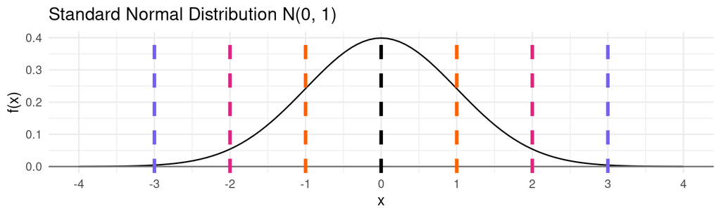

- approximately \(68\%\) of the curve’s area is between \(\mu \pm 1\sigma\)
- approximately \(95\%\) of the curve’s area is between \(\mu \pm 2\sigma\)
- approximately \(99.7\%\) of the curve’s area is between \(\mu \pm 3\sigma\)

The tails extend to \(\pm \infty\) ; any value of \(x\) is *theoretically* possible. In any given problem context, there will be limits on the values.

## Calculating the pdf or \(f(x)\)

Recall the normal model’s probability density function (pdf).

\[f(x)=\frac{1}{\sqrt{2\pi}\sigma}e^{-\frac{1}{2}\left(\frac{x-\mu}{\sigma}\right)^2}\]

R has a function to solve the pmf for any normal model. Inputs may be single values or vectors. *We only use this for plotting the normal distribution, not for calculating probabilities.*

\(f(x)\) = `dnorm(x, mean, sd)`

Note that the `R` function uses standard deviation (\(\sigma\)) rather than the variance (\(\sigma^2\)) as an input (argument) to the function.

```r
# plotting the standard normal (Z) pdf
ggplot() +
  stat_function(
    fun = dnorm,
    args = list(0, 1)
  ) +
  geom_hline(yintercept = 0, color = "#707070"
  ) +
  scale_x_continuous(
    limits = c(-4, 4),
    breaks = seq(from = -4, to = 4, by = 1)
  ) +
  labs(
    title = "Z ~ N(μ = 0, σ = 1)",
    x = "x",
    y = "f(x)"
  ) +
  theme_minimal()
```

The results of the code, with the pdf curve, shaded x-axis, and tick marks at \(1\sigma\) intervals.

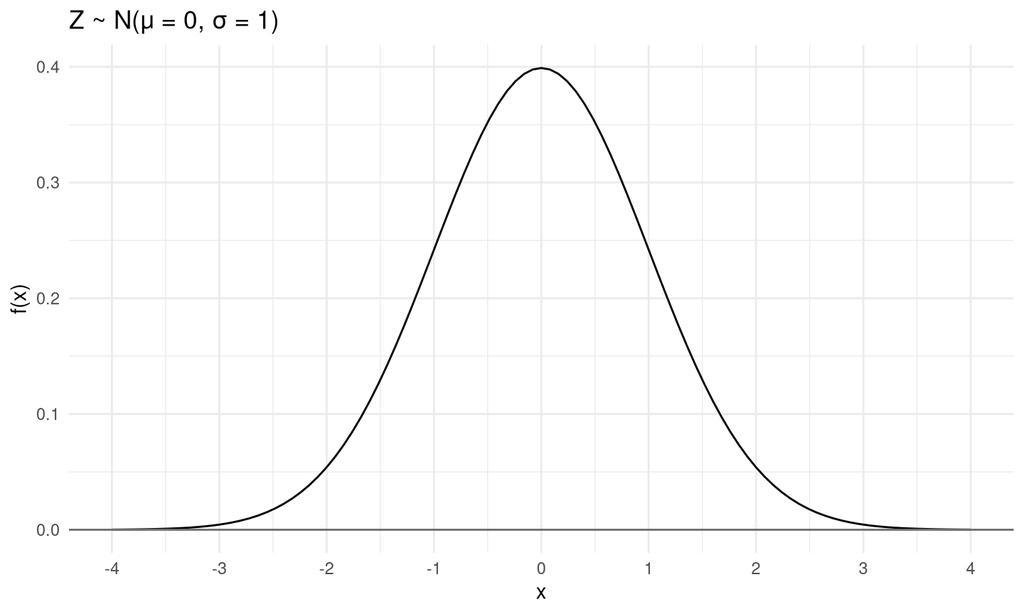

## General Plotting Code

The code is split across this slide and the next.

By inputting parameters as variables at the beginning, you only have to edit the labels for the problem context.

```r
# set the parameters of the normal model
mu  <- 0
sig <- 1

# adapt the labels for the given problem
ggplot() +
  stat_function(
    fun = dnorm,
    args = list(mu, sigma)
  ) +
```

Continued from the previous slide…

```r
  geom_hline(yintercept = 0, color = "#707070") +
  scale_x_continuous(
    limits = c(mu - (4 * sig), mu + (4 * sig)),
    breaks = seq(from = mu - (4 * sig), to = mu + (4 * sig), by = sig)
  ) +
  labs(
    title = "informative plot title",
    x = "description and units of x",
    y = "F(x)"
  ) +
  theme_minimal()
```

## Cumulative Distribution Function (CDF)

Recall also the normal model’s CDF.

\[F(x)=P(X \leq x) = \int\limits_{-\infty}^{x} \frac{1}{\sqrt{2\pi}\sigma}e^{-(x-\mu)^2/(2\sigma^2)}dx\]

\(P(X \leq x)\) = `pnorm(q, mean, sd, lower.tail = TRUE)`

\(P(X > x)\) = `pnorm(q, mean, sd, lower.tail = FALSE)`

For any continuous distribution \(P(X = x) = 0\) (area under a single point is zero). Therefore, \(P(X \leq x)\) and \(P(X < x)\) are mathematically equivalent. However, we might use a *continuity correction* when approximating discretely measured data.

```r
# plotting the standard normal (Z) CDF
ggplot() +
  stat_function(
    fun = pnorm,
    args = list(0, 1)
  ) +
  geom_hline(yintercept = 0, color = "#707070") +
  scale_x_continuous(
    limits = c(-4, 4),
    breaks = seq(from = -4, to = 4, by = 1)
  ) +
  labs(
    title = "Z ~ N(μ = 0, σ = 1)",
    x = "x",
    y = "F(x)"
  ) +
  theme_minimal()
```

The results of the code, with the CDF curve, shaded x-axis, and tick marks at \(1\sigma\) intervals.

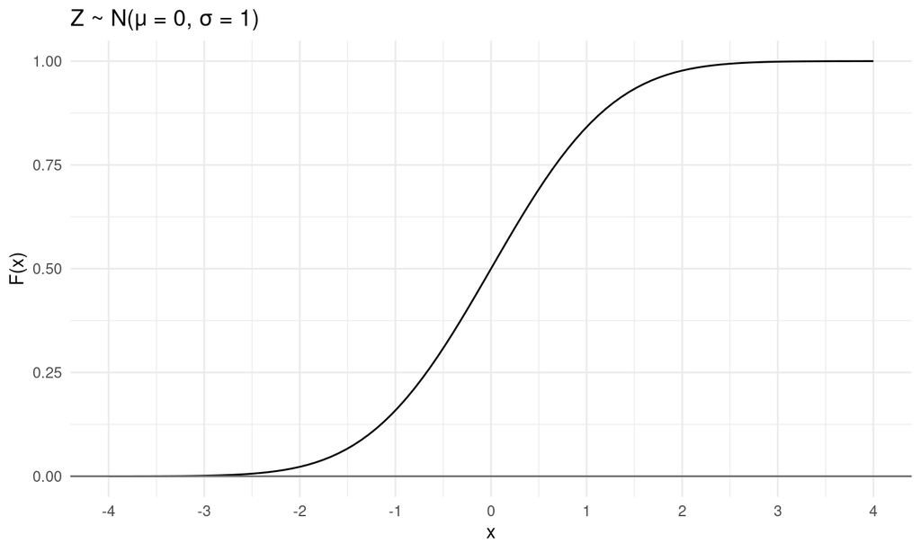

## General Plotting Code

The code is split across this slide and the next.

By inputting parameters as variables at the beginning, you only have to edit the labels for the problem context.

```r
# set the parameters of the normal model
mu  <- 0
sig <- 1

# adapt the labels for the given problem
ggplot() +
  stat_function(
    fun = pnorm,
    args = list(mu, sigma)
  ) +
  geom_hline(yintercept = 0, color = "#707070") +
```

Continued from the previous slide…

```r
  scale_x_continuous(
    limits = c(mu - (4 * sig), mu + (4 * sig)),
    breaks = seq(from = mu - (4 * sig), to = mu + (4 * sig), by = sig)
  ) +
  labs(
    title = "informative plot title",
    x = "description and units of x",
    y = "F(x)"
  ) +
  theme_minimal()
```

## Solving for Area Under the Curve #1

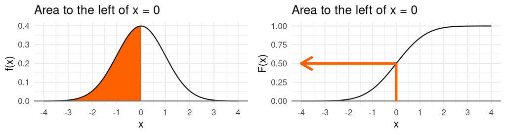

```r
pnorm(q = 0, mean = 0, sd = 1) #lower.tail = TRUE is the default
```

```
[1] 0.5
```

```r
pnorm(q = 0, mean = 0, sd = 1, lower.tail = FALSE) #area above 0
```

```
[1] 0.5
```

## Solving for Area Under the Curve #2

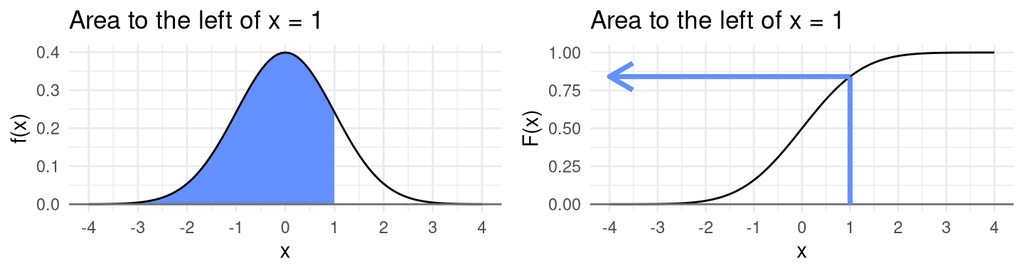

```r
pnorm(q = 1, mean = 0, sd = 1) #lower.tail = TRUE is the default
```

```
[1] 0.8413447
```

```r
pnorm(q = 1, mean = 0, sd = 1, lower.tail = FALSE) # area above 1
```

```
[1] 0.1586553
```

## Solving for Area Between Two Values

\[P(0 \leq X \leq 1) = \int\limits_{0}^{1}\frac{1}{\sqrt{2\pi}}e^{-\frac{1}{2}x^2}dx\]

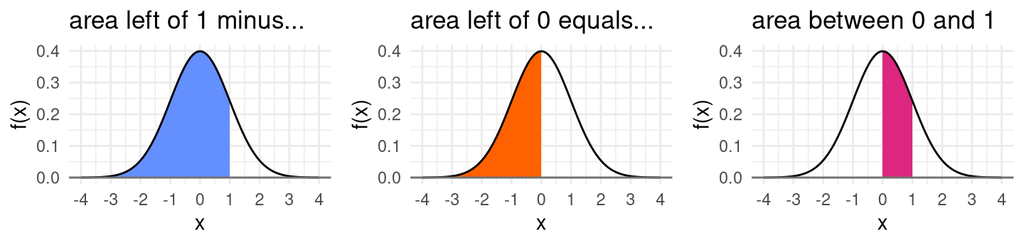

```r
pnorm(q = 1, mean = 0, sd = 1) - pnorm(q = 0, mean = 0, sd = 1)
```

```
[1] 0.3413447
```

## The Inverse CDF

In the discussions above, we found the area to the left of a given point (or *quantile*) on the x-axis. Sometimes we need to solve the reverse kind of problem: given an area or probability, what is the corresponding quantile or quantiles?

\(F^{-1}(x)\) = `qnorm(p, mean, sd, lower.tail = TRUE)`

If the area is to the right of the unknown value x (the upper tail) rather than to the left (the lower tail), then specify upper tail.

\(F^{-1}(x)\) = `qnorm(p, mean, sd, lower.tail = FALSE)`

If we know \(\mu\), \(\sigma\), and either the value(s) of x or the area(s)…

`qnorm(p, mean, sd) = q` \(\Longleftrightarrow\) `pnorm(q, mean, sd) = p`

## Solving for the Quantile

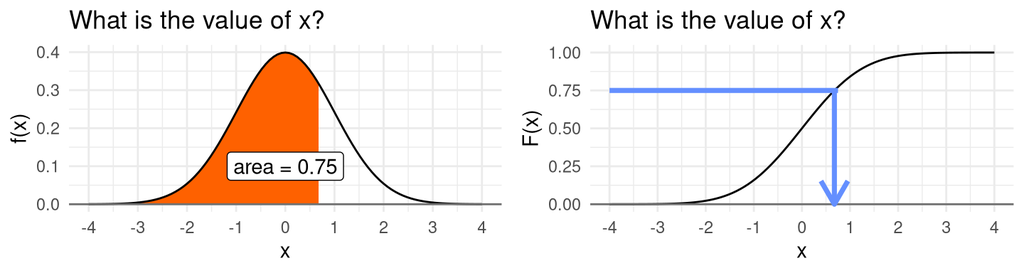

```r
(x_val <- qnorm(p = .75, mean = 0, sd = 1))
```

```
[1] 0.6744898
```

```r
pnorm(q = x_val, mean = 0, sd = 1)   # check the x, we get the area
```

```
[1] 0.75
```

## Sampling from a Normal Distribution

In addition to calculating probabilities, we can simulate random normal values in `R` using `rnorm(n, mean, sd)`.

*n* = the number of random values (sample size)

*mean* = the mean of the distribution

*sd* = the standard deviation of the distribution

As with the other *norm* functions, the default parameter settings in `rnorm()` are `mean = 0` and `sd = 1`.

If we want a sample from the standard normal distribution, we only need to enter a value for sample size, `rnorm(n)`.

```r
rnorm(5)
```

```
[1] -0.42514667  0.15827522 -0.20057130  0.01225451 -0.92287730
```

```r
rnorm(10)
```

```
 [1]  1.75780673 -0.58020883 -0.55042599 -0.54447430  1.08569283  0.06235409
 [7]  0.54166563  1.87304871 -1.00001485 -0.98251053
```

```r
rnorm(25)
```

```
 [1]  1.22676241 -0.43496777  0.15487137  0.21800597 -0.44683226  1.52815509
 [7]  0.46053517  1.39036003  1.37975240  0.53907259  1.94746553  2.59787604
[13] -0.02126329 -2.53493990  1.40718155  0.48992743 -1.18371818 -0.05677691
[19]  0.85645504  2.44968554 -0.26330551 -0.69185786  0.68962177 -0.15054483
[25] -0.55356120
```

## Plotting the Sample

```r
random_sample <- rnorm(100)

ggplot(NULL, aes(x = random_sample)) +
  geom_histogram(
    aes(y = after_stat(density)),
    bins = 20,
    fill = "skyblue",
    color = "white"
  ) +
  geom_density(linetype = "dashed") +
  geom_hline(yintercept = 0, color = "#707070") +
  scale_x_continuous(
    limits = c(-5, 5),
    breaks = seq(from = -5, to = 5, by = 1)
  ) +
  theme_minimal()
```

## Sample of Size 100

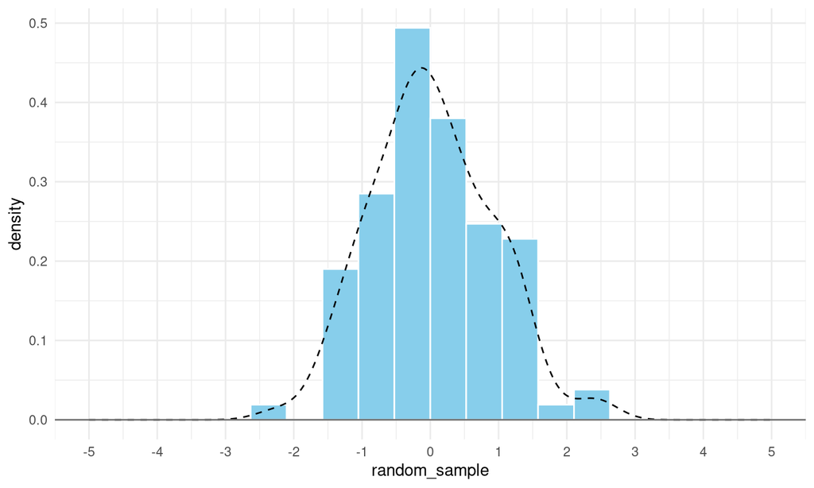

## Sample of Size 1000

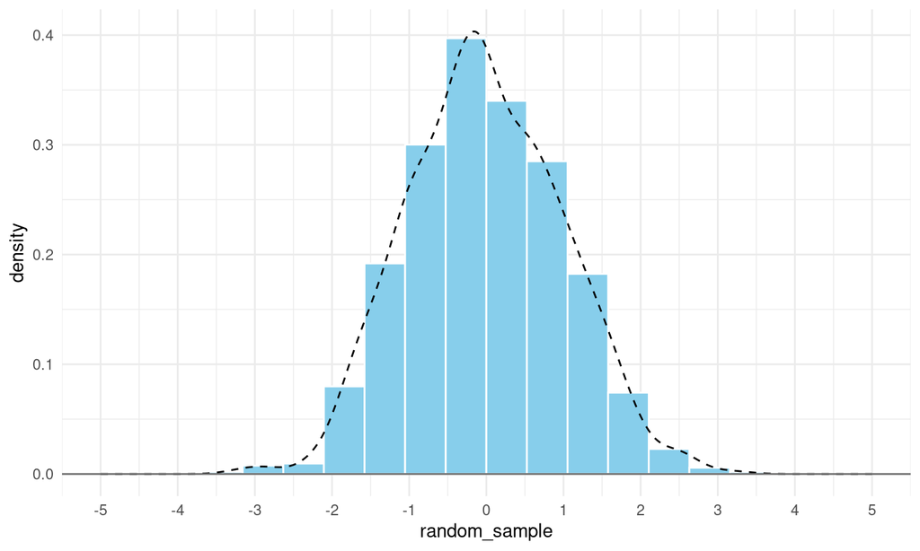

## Sample of Size 1,000,000

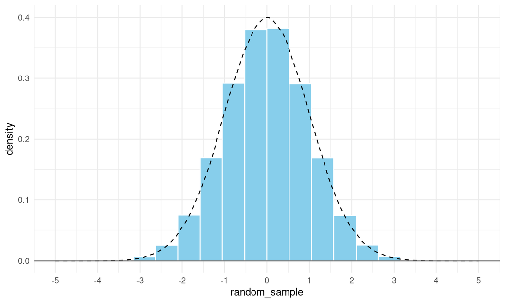

## Sample of Size 1,000,000

```r
tibble(x = random_sample) |>
  summarize(
    mean_x = mean(x),
    sd_x   = sd(x),
    min_x  = min(x),
    max_s  = max(x),
    plusminus_1SD  = sum(x >= -1 & x <= 1)/length(x),
    plusminus_2SD  = sum(x >= -2 & x <= 2)/length(x),
    plusminus_3SD  = sum(x >= -3 & x <= 3)/length(x)
  ) |>
kable(digits = 3, align = "c")
```

| mean_x | sd_x | min_x | max_s | plusminus_1SD | plusminus_2SD | plusminus_3SD |
| --- | --- | --- | --- | --- | --- | --- |
| 0 | 1 | -4.754 | 4.889 | 0.683 | 0.954 | 0.997 |